# DDP Final Project Pitch Presentation

Pratik A. Khare

2026-03-14

# Introduction

- This app predicts the probability of India winning a cricket match using **multinomial logistic regression** trained on historical match results
- The model takes three user-selected inputs namely, **opponent, venue, and format** (Test / ODI / T20), and returns the predicted probability of a Win, Loss, or Draw
- The model is simplistic in nature, considering only a few key variables. Additionally, it is trained on historical data. Past performance is not a guarantee of future results

# ML algorithm used and evaluation

The app uses a **multinomial logistic regression** model via the `multinom()` function from the `nnet` package. The model is trained on historical India match results, predicting outcome (Win/Loss/Draw) from opponent, venue, and format.

```r
library(readxl)
```

```r
library(nnet)

data <- read_excel("data/Ind vs opponent results.xlsx")
df <- subset(data, Result != "NR")
df$Result[df$Result %in% c("Tied","Draw")] <- "Draw"
df$Result <- factor(df$Result)
df$Opponent <- factor(df$Opponent)
df$Venue <- factor(df$Venue)
df$Format <- factor(df$Format)

model <- multinom(Result ~ Opponent + Venue + Format, data = df)
summary(model)
```

```
## Call:
## multinom(formula = Result ~ Opponent + Venue + Format, data = df)
##
## Coefficients:
##      (Intercept) OpponentEngland OpponentPakistan OpponentSouth Africa
## Loss    5.564669      -0.5569458        -1.551056            0.2923433
## Win     4.810498      -0.2380381        -1.438593            0.4048800
##      OpponentWest Indies  VenueHome VenueNeutral FormatT20 FormatTest
## Loss          -0.9534112 -0.3348392     10.57441  7.999503  -4.934941
## Win           -0.6323947  0.4819899     11.23608  8.695043  -5.078633
##
## Std. Errors:
##      (Intercept) OpponentEngland OpponentPakistan OpponentSouth Africa
## Loss   0.7515430       0.2852758        0.3506165            0.4222167
## Win    0.7553691       0.2951833        0.3626136            0.4329006
##      OpponentWest Indies VenueHome VenueNeutral FormatT20 FormatTest
## Loss           0.2996347 0.2078663     205.1103  106.8301  0.7219215
## Win            0.3088540 0.2151487     205.1104  106.8301  0.7234679
##
## Residual Deviance: 1961.951
## AIC: 1997.951
```

# Results in graphical format

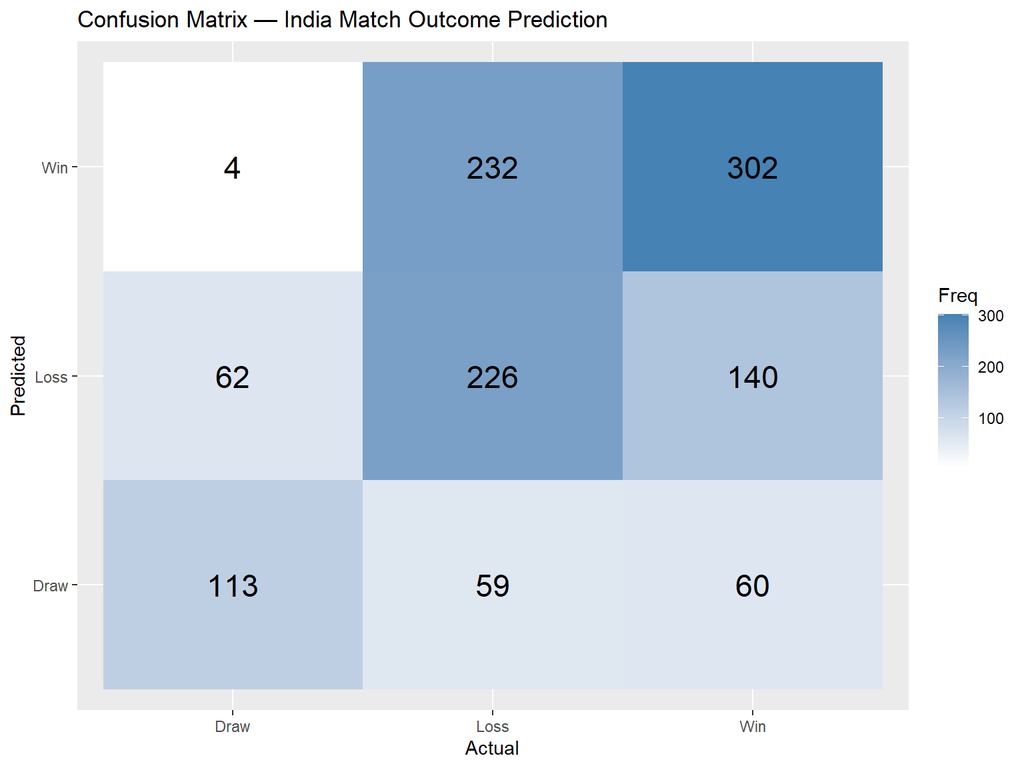

# Note on Data Collection

- Match results data was manually compiled from **ESPN Cricinfo**, covering India’s international matches across Test, ODI, and T20 formats against five major opponents: Australia, England, South Africa, Pakistan, and West Indies
- Each record contains four variables: **Opponent, Venue, Format, and Result**. Venue is categorized as Home, Away, or Neutral. No-result (NR) matches were excluded, and Tied/Drawn matches were merged into a single **Draw** category
- The dataset is limited in scope; only five opponents are included, and historical factors such as team composition, player form, and pitch conditions are not captured. Users should interpret predictions accordingly